# 209.1. Object table flags

For the Rubin Science Platform at data.lsst.cloud.  
Data Release: [Data Preview 2](https://dp2.lsst.io)  
Container Size: Large  
LSST Science Pipelines version: r30.0.11  
Last verified to run: 10-22-2026  
Repository: github.com/lsst/tutorial-notebooks  
DOI: 10.11578/rubin/dc.20250909.20

**Learning objective:** To characterize the flag columns of the `Object` table.

**LSST data products:** `Object`

**Packages:** `numpy`, `matplotlib`, `lsst.rsp.RSPDiscovery`, `lsst.utils.plotting`

**Credit:** Originally developed by the Rubin Community Science team. Please consider acknowledging them if this notebook is used for the preparation of journal articles, software releases, or other notebooks.

**Get Support:** Everyone is encouraged to ask questions or raise issues in the [Support Category](https://community.lsst.org/c/support/6) of the Rubin Community Forum. Rubin staff will respond to all questions posted there.

## 1. Introduction

A flag column is a boolean column that records a condition found during processing: a measurement failed, a pixel in the footprint carried a mask bit, or a special case was identified. A value of `True` (`1` in Astronomical Data Query Language, ADQL) means the condition occurred.

In the `Object` table the naming pattern is `{band}_{measurement}_flag`, where `{band}` is one of `u`, `g`, `r`, `i`, `z`, `y`. Most algorithms provide a general failure flag, set for any failure, plus detailed subflags that record what went wrong. The `{band}_pixelFlags_*` columns report the mask-plane status of the pixels in the object's footprint on the coadd.

More information on flag columns can be found in the [catalog flag columns](https://dp2.lsst.io/products/flags/) pages on dp2.lsst.io.

**Related tutorials:** The contents of the `Object` table are described in the 200-level tutorial on the `Object` table. The image mask planes behind the `pixelFlags_*` columns are described in the 200-level tutorial on pixel mask planes. The TAP service is introduced in the 100-level "How to" tutorials.

### 1.1. Import packages

Import `numpy` for arrays and `matplotlib` for plots.

From the `lsst` package, import `RSPDiscovery` for the data services and `set_rubin_plotstyle` for the Rubin plot style.

```python
import numpy as np
import matplotlib.pyplot as plt
from lsst.rsp import RSPDiscovery
from lsst.utils.plotting import set_rubin_plotstyle
```

### 1.2. Define parameters and functions

#### 1.2.1. Instantiate the TAP service

Instantiate `RSPDiscovery` with the DP2 data release and get the TAP client.

```python
discovery = RSPDiscovery("dp2")
service = discovery.get_tap_client()
```

#### 1.2.2. Define the plot defaults and the sky region

Set the Rubin plot style, and define line styles to distinguish plotted series without relying on color.

Define the sky region: a cone of radius 0.05 degrees on the Extended Chandra Deep Field South (ECDFS), one of the DP2 Deep Drilling Fields. A Deep Drilling Field has many more input visits than the wide survey area, so flags that depend on the number of inputs behave differently there.

Keep the radius small. The deep coadd footprint of a DP2 field can be considerably smaller than the field itself, and a cone that extends past it returns objects with no coadd coverage in this band, whose flags describe the missing data rather than the objects. Section 2.2 checks the coverage of this cone before any flag is interpreted.

```python
set_rubin_plotstyle()
%matplotlib inline

line_styles = ['-', '--', '-.', ':', (0, (3, 1, 1, 1)), (0, (5, 1))]

ecdfs_ra = 53.0
ecdfs_dec = -28.1
radius = 0.05
```

#### 1.2.3. Define functions to query the table and unpack its columns

Define three helper functions used throughout.

`run_query` submits an Astronomical Data Query Language (ADQL) query as an asynchronous TAP job, waits for it, and returns an `astropy` table. Deleting the job releases the resources it holds on the server.

`get_float_column` and `get_flag_column` extract one column as a plain `numpy` array. They exist because TAP returns masked columns, and a comparison involving a masked entry returns a masked value rather than `True` or `False`. That can drop rows from a selection with no error raised. Converting up front makes the treatment of missing entries explicit: `get_float_column` fills them with `NaN`, which `numpy.isfinite` detects, and `get_flag_column` fills them with `False`, meaning the condition was not recorded.

```python
def run_query(query):
    """Submit an ADQL query as an async job and return an astropy table.

    Parameters
    ----------
    query : `str`
        The ADQL query to execute.

    Returns
    -------
    table : `astropy.table.Table`
        The query results.
    """
    job = service.submit_job(query)
    job.run()
    job.wait(phases=['COMPLETED', 'ERROR'])
    print('Job phase is', job.phase)
    if job.phase == 'ERROR':
        job.raise_if_error()
    assert job.phase == 'COMPLETED'
    table = job.fetch_result().to_table()
    job.delete()
    return table


def get_float_column(table, name):
    """Return a float column as a plain array, with masked entries as NaN.

    Parameters
    ----------
    table : `astropy.table.Table`
        The table to extract the column from.
    name : `str`
        The name of the column.

    Returns
    -------
    values : `numpy.ndarray`
        The column values, as floats.
    """
    return np.asarray(np.ma.filled(table[name].astype(float), np.nan))


def get_flag_column(table, name):
    """Return a flag column as a plain boolean array, masked entries as False.

    Parameters
    ----------
    table : `astropy.table.Table`
        The table to extract the column from.
    name : `str`
        The name of the flag column.

    Returns
    -------
    values : `numpy.ndarray`
        The column values, as booleans.
    """
    return np.asarray(np.ma.filled(table[name], False)).astype(bool)
```

#### 1.2.4. Define a function to measure the impact of a set of cuts

The characterization below uses keep masks. A keep mask is a boolean array with one entry per row, `True` where the row passes that cut. A set of cuts is a dictionary mapping a label to its keep mask, and the surviving sample is the logical AND of all the masks.

`report_cut_impact` prints three numbers per cut.

- `rm alone`: rows that cut removes on its own, ignoring the other cuts.
- `rm uniquely`: rows that cut removes that all the other cuts would have kept. A value of zero means the cut is redundant and could be deleted without changing the sample.
- `cum kept`: rows surviving that cut and every cut listed above it. This column depends on the dictionary order; the other two do not.

A worked example with three rows and two cuts shows the difference between the first two.

| row | cut A | cut B | removed by |
| --- | --- | --- | --- |
| 1 | pass | pass | nothing |
| 2 | fail | fail | both |
| 3 | fail | pass | A only |

Cut A removes rows 2 and 3, so its `rm alone` is 2. Its `rm uniquely` is 1, because cut B would have removed row 2 anyway. Cut B has `rm alone` of 1 and `rm uniquely` of 0, so B is redundant here.

Note that `rm alone` does not sum to the number of rows removed. Here it sums to 3, but only 2 rows are lost, because overlapping cuts count the same row twice.

The function returns the combined keep mask for reuse below.

```python
def report_cut_impact(keep_masks, label='sample'):
    """Print a per-cut breakdown for a dict of cuts and return the joint mask.

    Parameters
    ----------
    keep_masks : `dict` [`str`, `numpy.ndarray`]
        Cut labels mapped to boolean arrays that are True where a row passes
        that cut.
    label : `str`, optional
        A name for the sample, used in the summary line.

    Returns
    -------
    all_pass : `numpy.ndarray`
        Boolean array, True where a row passes every cut in `keep_masks`.
    """
    names = list(keep_masks)
    n_total = len(keep_masks[names[0]])
    all_pass = np.logical_and.reduce(list(keep_masks.values()))

    print('{}: {} rows before any cuts, {} after all cuts '
          '({:.2f}% removed)'.format(label, n_total, np.sum(all_pass),
                                     100.0 * np.sum(~all_pass) / n_total))
    print('{:<38s} {:>12s} {:>12s} {:>12s}'.format(
        'cut', 'rm alone', 'rm uniquely', 'cum kept'))

    running = np.ones(n_total, dtype=bool)
    for name in names:
        mask = keep_masks[name]
        others = [m for other, m in keep_masks.items() if other != name]
        if others:
            pass_others = np.logical_and.reduce(others)
        else:
            pass_others = np.ones(n_total, dtype=bool)
        running = running & mask
        print('{:<38s} {:>12d} {:>12d} {:>12d}'.format(
            name, np.sum(~mask), np.sum(~mask & pass_others),
            np.sum(running)))

    return all_pass
```

## 2. Retrieve an unfiltered sample of objects

### 2.1. Query the Object table without any flag cuts

Define a query that returns the $i$-band photometry and every flag column used below, for all objects in the ECDFS cone.

The query applies no flag cuts, so that the cuts can be built and switched off in python afterwards. It also returns `i_inputCount`, the number of coadd inputs at the object's center, which is an integer but is used the same way, and `i_cModelMag`, which is needed for the exercises in Section 6.

The list includes `i_pixelFlags_nodata`, which reports that no pixel data was available in this band for the object. An object appears in the `Object` table if it was detected in any band, so an object can have no data at all in a given band and still have a row.

No de-duplication or deblending cut is needed. The DP2 `Object` table is delivered as deblended children only, with duplicates in overlapping patch edges already rejected.

```python
columns = ['objectId', 'coord_ra', 'coord_dec', 'refBand',
           'i_psfMag', 'i_psfMagErr', 'i_cModelMag', 'i_inputCount',
           'i_i_flag', 'i_psfFlux_flag', 'i_cModel_flag', 'i_invalidPsfFlag',
           'i_pixelFlags_saturatedCenter', 'i_pixelFlags_saturated',
           'i_pixelFlags_interpolatedCenter', 'i_pixelFlags_interpolated',
           'i_pixelFlags_crCenter',
           'i_pixelFlags_sensor_edge', 'i_pixelFlags_sensor_edgeCenter',
           'i_pixelFlags_nodata',
           'i_pixelFlags_bad', 'i_pixelFlags_edge', 'i_pixelFlags_suspect',
           'i_pixelFlags_suspectCenter', 'i_pixelFlags_offimage']

query = "SELECT " + ", ".join(columns) + " " \
        "FROM dp2.Object " \
        "WHERE CONTAINS(POINT('ICRS', coord_ra, coord_dec), " \
        "CIRCLE('ICRS', {}, {}, {})) = 1".format(ecdfs_ra, ecdfs_dec, radius)
print(query)
```

[output not shown]

Run the query and report how many objects were returned.

```python
objects = run_query(query)
n_objects = len(objects)
print(n_objects, 'objects retrieved, with no flag cuts applied')
```

```
Job phase is COMPLETED
```

```
2614 objects retrieved, with no flag cuts applied
```

### 2.2. Check the coadd coverage of the sample

Check the coverage before reading any flag. An object appears in the `Object` table if it was detected in any band, so a cone that extends beyond the deep coadd footprint in this band returns objects whose every $i$-band measurement necessarily failed. Flag occupancies measured on such a sample describe the missing coverage, not the flags.

Three numbers settle it: the number of coadd inputs at the object positions, the fraction with `i_pixelFlags_nodata` set, and the fraction with a finite `i_psfMag`.

`refBand` gives the band each object's forced measurements are referenced to. A sample dominated by a band other than the one under study is another sign of thin coverage.

```python
input_count = get_float_column(objects, 'i_inputCount')
psf_mag_finite = np.isfinite(get_float_column(objects, 'i_psfMag'))
nodata = get_flag_column(objects, 'i_pixelFlags_nodata')

print('i_inputCount: min {:.0f}, median {:.0f}, max {:.0f}'.format(
    np.nanmin(input_count), np.nanmedian(input_count),
    np.nanmax(input_count)))
print('fraction with i_pixelFlags_nodata set: {:.4f}'.format(
    np.sum(nodata) / n_objects))
print('fraction with a finite i_psfMag:       {:.4f}'.format(
    np.sum(psf_mag_finite) / n_objects))

ref_band = np.asarray(np.ma.filled(objects['refBand'], '?')).astype(str)
print('refBand:', ', '.join(
    ['{} {}'.format(value, int(np.sum(ref_band == value)))
     for value in sorted(set(ref_band))]))
```

```
i_inputCount: min 60, median 72, max 79
fraction with i_pixelFlags_nodata set: 0.0226
fraction with a finite i_psfMag:       0.9858
refBand: g 129, i 2157, r 54, u 73, y 101, z 100
```

A median input count in the tens, a `nodata` fraction of a few percent, and a finite magnitude for nearly every object mean the cone is well inside the coadd footprint and the flags below describe the objects.

A median input count of one or two, with a large `nodata` fraction, means the opposite. In that case reduce the radius or move the center before going further, because every occupancy below will be dominated by objects that have no data in this band.

### 2.3. Measure how often each flag is set

Measure the occupancy of each flag: the fraction of objects for which it is set. This separates the flags that will drive a selection from those that are set for almost nothing.

Collect the flag columns as boolean arrays for reuse.

```python
flag_names = [name for name in columns if 'flag' in name.lower()]
flags = {name: get_flag_column(objects, name) for name in flag_names}

print('{:<38s} {:>10s} {:>10s}'.format('flag column', 'n set', 'fraction'))
for name in flag_names:
    n_set = np.sum(flags[name])
    print('{:<38s} {:>10d} {:>10.5f}'.format(name, n_set,
                                             n_set / n_objects))
```

```
flag column                                 n set   fraction
i_i_flag                                      641    0.24522
i_psfFlux_flag                                247    0.09449
i_cModel_flag                                  91    0.03481
i_invalidPsfFlag                                0    0.00000
i_pixelFlags_saturatedCenter                   39    0.01492
i_pixelFlags_saturated                         90    0.03443
i_pixelFlags_interpolatedCenter                20    0.00765
i_pixelFlags_interpolated                     324    0.12395
i_pixelFlags_crCenter                          18    0.00689
i_pixelFlags_sensor_edge                        0    0.00000
i_pixelFlags_sensor_edgeCenter                  0    0.00000
i_pixelFlags_nodata                            59    0.02257
i_pixelFlags_bad                                0    0.00000
i_pixelFlags_edge                               0    0.00000
i_pixelFlags_suspect                            0    0.00000
i_pixelFlags_suspectCenter                      0    0.00000
i_pixelFlags_offimage                           0    0.00000
```

Plot the same fractions, sorted, on a logarithmic axis. The fractions span several orders of magnitude.

Flags that are set for no object are plotted at half of one object, so that they stay visible.

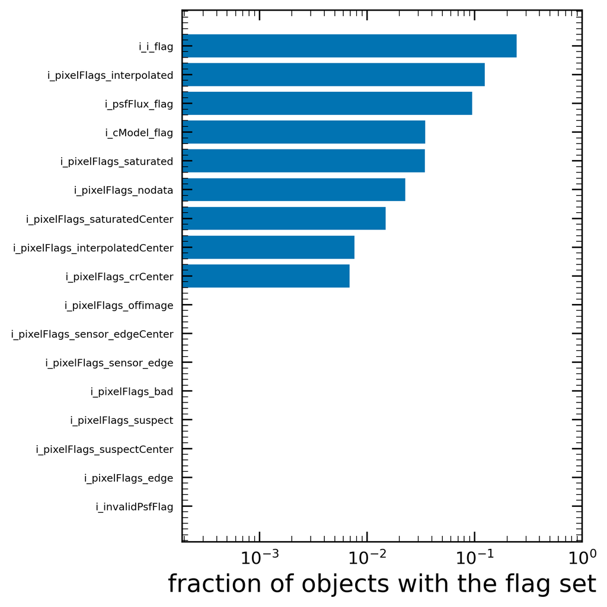

```python
fractions = np.array([np.sum(flags[name]) / n_objects
                      for name in flag_names])
order = np.argsort(fractions)
floor = 0.5 / n_objects

fig, ax = plt.subplots(figsize=(6, 6))
ax.barh(np.arange(len(flag_names)),
        np.clip(fractions[order], floor, None))
ax.set_yticks(np.arange(len(flag_names)))
ax.set_yticklabels([flag_names[i] for i in order], fontsize=7)
ax.set_xscale('log')
ax.set_xlim(floor, 1.0)
ax.set_xlabel('fraction of objects with the flag set')
plt.tight_layout()
plt.show()
```

### 2.4. The general failure flag `{band}_i_flag`

The name `{band}_i_flag`, which for the $i$ band becomes `i_i_flag`, is easy to misread.

The two letters differ in meaning. The first is the band prefix carried by every per-band `Object` column. The second is the symbol for the adaptive second moments of the object's light, stored in `{band}_ixx`, `{band}_iyy`, and `{band}_ixy`. So `{band}_i_flag` is the general failure flag of the moments measurement, and the $u$-band version of the same flag is `u_i_flag`. The schema describes it as "General failure flag, set if anything went wrong". The companion flag for the moments of the PSF model is `{band}_iPSF_flag`.

This flag illustrates the general rule in the [flag use examples](https://dp2.lsst.io/products/flags/): when a measured quantity is used, require that quantity's own general failure flag to be `0`. Require `{band}_i_flag` for the second moments, `{band}_psfFlux_flag` for the PSF flux, and `{band}_cModel_flag` for the CModel fluxes. An analysis that uses only fluxes does not need `{band}_i_flag`.

A general failure flag can be set while none of its subflags are set. The subflags record specific failure modes of the algorithm, so a failure that happens before the algorithm runs at all, such as the band having no pixel data, sets the general flag alone. Treat the subflags as diagnostic, not exhaustive.

Compare its occupancy with the two flux failure flags, and measure the overlap.

```python
general_flags = ['i_i_flag', 'i_psfFlux_flag', 'i_cModel_flag']

print('{:<22s} {:>10s} {:>10s}'.format('flag', 'n set', 'fraction'))
for name in general_flags:
    print('{:<22s} {:>10d} {:>10.5f}'.format(
        name, np.sum(flags[name]), np.sum(flags[name]) / n_objects))

print()
print('{:<22s} {:>12s} {:>12s}'.format(
    'flag', 'also psfFlux', 'also cModel'))
for name in general_flags:
    print('{:<22s} {:>12d} {:>12d}'.format(
        name,
        np.sum(flags[name] & flags['i_psfFlux_flag']),
        np.sum(flags[name] & flags['i_cModel_flag'])))
```

```
flag                        n set   fraction
i_i_flag                      641    0.24522
i_psfFlux_flag                247    0.09449
i_cModel_flag                  91    0.03481

flag                   also psfFlux  also cModel
i_i_flag                        245           69
i_psfFlux_flag                  247           59
i_cModel_flag                    59           91
```

The three general failure flags are not interchangeable. An object whose moments failed can still have a good PSF flux, and an object whose CModel fit failed can still have good moments.

Require all three only for an analysis that uses all three quantities. Requiring the wrong one discards objects for no benefit and leaves the quantity in use unprotected.

## 3. Characterize a set of flag cuts

### 3.1. Express the cuts as individual keep masks

Build a baseline set of cuts for an analysis that uses the $i$-band PSF flux. This set follows the minimal set in the [flag use examples](https://dp2.lsst.io/products/flags/) for the `Object` table.

| cut | what it protects against |
| --- | --- |
| `i_inputCount > 0` | the coadd has no input image at this position in this band |
| `i_psfFlux_flag = 0` | the PSF flux measurement failed |
| `i_invalidPsfFlag = 0` | there is no usable PSF model at the position |
| `i_pixelFlags_saturatedCenter = 0` | a saturated pixel sits in the central 3x3 box |
| `i_pixelFlags_interpolatedCenter = 0` | a central pixel was interpolated, not measured |

Write each cut as a separate keep mask, rather than one compound expression, so that each can be examined and removed independently.

Wrap the set in a function of the table so that the same cuts can be applied to another sample in Section 5 without restating them.

```python
def build_cuts(table):
    """Return the baseline set of i-band cuts for an Object table.

    Parameters
    ----------
    table : `astropy.table.Table`
        A table with the flag columns retrieved in Section 2.1.

    Returns
    -------
    cuts : `dict` [`str`, `numpy.ndarray`]
        Cut labels mapped to boolean keep masks.
    """
    return {
        'i_inputCount > 0': get_float_column(table, 'i_inputCount') > 0,
        'i_psfFlux_flag = 0': ~get_flag_column(table, 'i_psfFlux_flag'),
        'i_invalidPsfFlag = 0': ~get_flag_column(table, 'i_invalidPsfFlag'),
        'i_pixelFlags_saturatedCenter = 0':
            ~get_flag_column(table, 'i_pixelFlags_saturatedCenter'),
        'i_pixelFlags_interpolatedCenter = 0':
            ~get_flag_column(table, 'i_pixelFlags_interpolatedCenter'),
    }


cuts = build_cuts(objects)
```

### 3.2. Measure how much each cut removes

Pass the set of cuts to `report_cut_impact` for the breakdown described in Section 1.2.4.

```python
keep = report_cut_impact(cuts, label='Object, i band')
```

```
Object, i band: 2614 rows before any cuts, 2334 after all cuts (10.71% removed)
cut                                        rm alone  rm uniquely     cum kept
i_inputCount > 0                                  0            0         2614
i_psfFlux_flag = 0                              247          223         2367
i_invalidPsfFlag = 0                              0            0         2367
i_pixelFlags_saturatedCenter = 0                 39           14         2351
i_pixelFlags_interpolatedCenter = 0              20           17         2334
```

Read the `rm uniquely` column first. A cut whose value is zero removes nothing the rest of the set would not remove anyway.

That is common among pixel flags, because the conditions are correlated. An object with a saturated central pixel usually has interpolated central pixels too, since saturated pixels are interpolated over.

### 3.3. Remove the cuts one at a time

State the same result as a sample size. For each cut, drop it, re-apply the rest, and report how many objects survive.

This answers directly what a cut costs. Do it before adopting any set of cuts, because the answer depends on the field. A cut that is redundant in a Deep Drilling Field, where every position has many inputs, can dominate in a region observed a few times. Section 5 measures that.

```python
n_all_cuts = np.sum(keep)
print('all {} cuts applied: {} objects kept'.format(len(cuts), n_all_cuts))
print()
print('{:<38s} {:>12s} {:>12s}'.format(
    'cut dropped', 'kept', 'recovered'))
for name in cuts:
    remaining = [mask for other, mask in cuts.items() if other != name]
    n_kept = np.sum(np.logical_and.reduce(remaining))
    print('{:<38s} {:>12d} {:>12d}'.format(
        name, n_kept, n_kept - n_all_cuts))
```

```
all 5 cuts applied: 2334 objects kept

cut dropped                                    kept    recovered
i_inputCount > 0                               2334            0
i_psfFlux_flag = 0                             2557          223
i_invalidPsfFlag = 0                           2334            0
i_pixelFlags_saturatedCenter = 0               2348           14
i_pixelFlags_interpolatedCenter = 0            2351           17
```

### 3.4. Visualize which objects the cuts remove

Plot the kept and removed objects in the magnitude-uncertainty plane and on the sky.

A few objects have near-zero or negative flux, which gives a meaningless magnitude of tens of mag. Restrict the left panel to a sensible range, and report how many objects that excludes.

```python
mag = get_float_column(objects, 'i_psfMag')
mag_err = get_float_column(objects, 'i_psfMagErr')
ra = get_float_column(objects, 'coord_ra')
dec = get_float_column(objects, 'coord_dec')

mag_range = (14.0, 30.0)
shown = np.isfinite(mag) & np.isfinite(mag_err) \
    & (mag > mag_range[0]) & (mag < mag_range[1])
print('{} of {} objects fall outside the plotted magnitude range'.format(
    np.sum(~shown), n_objects))
```

```
75 of 2614 objects fall outside the plotted magnitude range
```

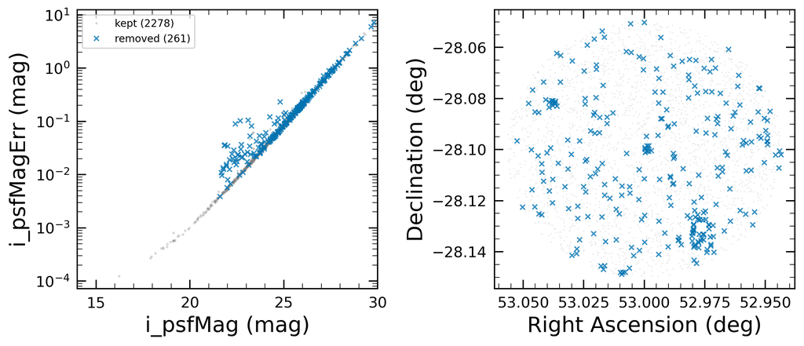

```python
fig, (ax1, ax2) = plt.subplots(1, 2, figsize=(9, 4))

kept_shown = keep & shown
removed_shown = ~keep & shown
ax1.plot(mag[kept_shown], mag_err[kept_shown], 'o', ms=2, mew=0, alpha=0.3,
         color='grey', label='kept ({})'.format(np.sum(kept_shown)))
ax1.plot(mag[removed_shown], mag_err[removed_shown], 'x', ms=4, mew=1.0,
         alpha=0.8, label='removed ({})'.format(np.sum(removed_shown)))
ax1.set_xlabel('i_psfMag (mag)')
ax1.set_ylabel('i_psfMagErr (mag)')
ax1.set_yscale('log')
ax1.set_xlim(*mag_range)
ax1.legend(loc='upper left', fontsize=8)

ax2.plot(ra[keep], dec[keep], 'o', ms=1, mew=0, alpha=0.2, color='grey')
ax2.plot(ra[~keep], dec[~keep], 'x', ms=4, mew=1.0, alpha=0.8)
ax2.set_xlabel('Right Ascension (deg)')
ax2.set_ylabel('Declination (deg)')
ax2.invert_xaxis()

plt.tight_layout()
plt.show()
```

> **Figure 2:** Two scatter plots. At left, $i$-band PSF magnitude on the horizontal axis against its uncertainty on a logarithmic vertical axis, for the objects kept by the baseline set, drawn as small round points, and the objects it removes, drawn as crosses. The axes are clipped, because a few objects with near-zero or negative flux have magnitudes far off scale. At right, the same two populations in Right Ascension and Declination. Whether the removed objects concentrate at bright magnitudes, at faint magnitudes, or at particular positions depends on which cut dominates the set.

### 3.5. Compare the magnitude distribution of the objects each cut removes

Break the removals down by cut. Histogram the magnitudes of the objects each individual cut removes, to identify the failure mode each cut protects against.

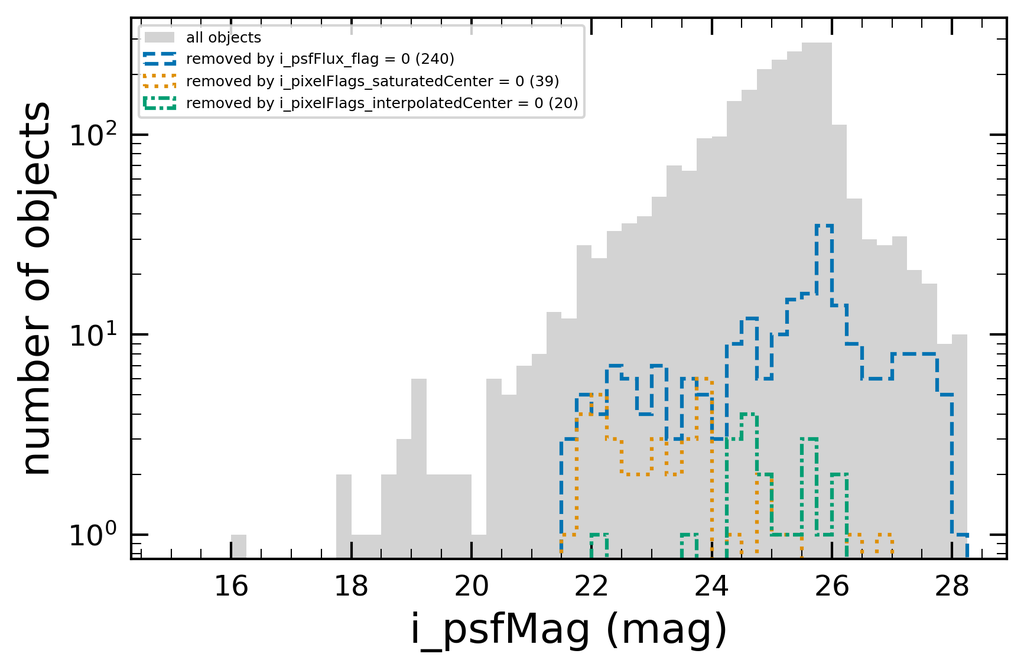

```python
bins = np.arange(15.0, 28.5, 0.25)
finite = np.isfinite(mag)

fig, ax = plt.subplots(figsize=(6, 4))
ax.hist(mag[finite], bins=bins, color='lightgrey', label='all objects')
for index, (name, cut) in enumerate(cuts.items()):
    removed = mag[~cut & finite]
    if len(removed) > 0:
        ax.hist(removed, bins=bins, histtype='step', lw=1.5,
                ls=line_styles[index % len(line_styles)],
                label='removed by {} ({})'.format(name, len(removed)))
ax.set_xlabel('i_psfMag (mag)')
ax.set_ylabel('number of objects')
ax.set_yscale('log')
ax.legend(fontsize=6)
plt.tight_layout()
plt.show()
```

### 3.6. Add stricter cuts

To switch a cut off, drop it from the set; to add one, add it. Define the stricter, science-case-dependent cuts from the flag use examples page and measure what they add.

| cut | what it adds |
| --- | --- |
| `i_pixelFlags_crCenter = 0` | rejects a cosmic ray at the center |
| `i_pixelFlags_interpolated = 0` | rejects any interpolated pixel in the footprint |
| `i_i_flag = 0` | rejects a failed second-moments measurement |

```python
def build_stricter_cuts(table):
    """Return the stricter, science-case-dependent i-band cuts.

    Parameters
    ----------
    table : `astropy.table.Table`
        A table with the flag columns retrieved in Section 2.1.

    Returns
    -------
    cuts : `dict` [`str`, `numpy.ndarray`]
        Cut labels mapped to boolean keep masks.
    """
    return {
        'i_pixelFlags_crCenter = 0':
            ~get_flag_column(table, 'i_pixelFlags_crCenter'),
        'i_pixelFlags_interpolated = 0':
            ~get_flag_column(table, 'i_pixelFlags_interpolated'),
        'i_i_flag = 0': ~get_flag_column(table, 'i_i_flag'),
    }


keep_strict = report_cut_impact({**cuts, **build_stricter_cuts(objects)},
                                label='Object, i band, baseline + stricter')
```

```
Object, i band, baseline + stricter: 2614 rows before any cuts, 1736 after all cuts (33.59% removed)
cut                                        rm alone  rm uniquely     cum kept
i_inputCount > 0                                  0            0         2614
i_psfFlux_flag = 0                              247            1         2367
i_invalidPsfFlag = 0                              0            0         2367
i_pixelFlags_saturatedCenter = 0                 39           10         2351
i_pixelFlags_interpolatedCenter = 0              20            0         2334
i_pixelFlags_crCenter = 0                        18            0         2334
i_pixelFlags_interpolated = 0                   324          208         2099
i_i_flag = 0                                    641          363         1736
```

Compare the magnitude distribution of the surviving sample under both selections, and with no cuts.

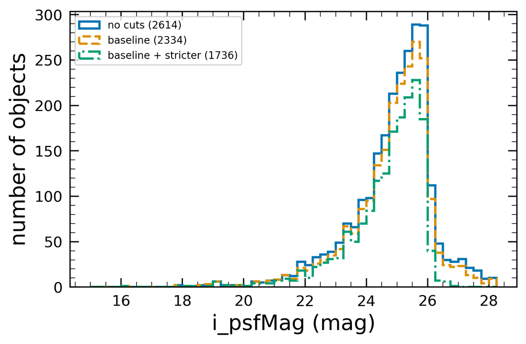

```python
variants = {
    'no cuts': np.ones(n_objects, dtype=bool),
    'baseline': keep,
    'baseline + stricter': keep_strict,
}

fig, ax = plt.subplots(figsize=(6, 4))
for index, (name, mask) in enumerate(variants.items()):
    ax.hist(mag[mask & finite], bins=bins, histtype='step', lw=1.8,
            ls=line_styles[index % len(line_styles)],
            label='{} ({})'.format(name, np.sum(mask)))
ax.set_xlabel('i_psfMag (mag)')
ax.set_ylabel('number of objects')
ax.legend(fontsize=8)
plt.tight_layout()
plt.show()
```

> **Figure 4:** Histogram of $i$-band PSF magnitude on the horizontal axis against number of objects on the vertical axis, for three selections drawn in different line styles: no flag cuts, the baseline set from Section 3.1, and the baseline set plus the stricter cuts. The vertical gap between two curves at a given magnitude is the completeness cost of the extra cuts there. A selection that removes a magnitude-dependent fraction changes the shape of the distribution, not only its normalization.

## 4. Flags that are deprecated in the Object table

Seven `pixelFlags` columns are deprecated in the DP2 `Object` table: `{band}_pixelFlags_bad`, `{band}_pixelFlags_edge`, `{band}_pixelFlags_suspect`, `{band}_pixelFlags_suspectCenter`, `{band}_pixelFlags_offimage`, `{band}_pixelFlags_sensor_edge`, and `{band}_pixelFlags_sensor_edgeCenter`.

They remain in the schema, and the first five remain meaningful in the `Source`, `ForcedSource`, and `DiaSource` tables, which are measured on individual visit images.

A cut on any of them in the `Object` table runs without error. The cell below shows how often each is set in this sample.

Whether these columns are set depends on the band's coadd coverage in the region. In a band that has coadd inputs, they are set for no object in the fields examined here. In a band that has no coadd at all in the region, they are set for every object, and `{band}_inputCount` is -1 rather than a count. The `{band}_inputCount > 0` cut of Section 3.1 therefore removes those objects already.

For positions with no pixel data in a band, use `{band}_pixelFlags_nodata`, as in Section 2.2.

Contrast how often each deprecated flag is set with the pixel flags that are valid here.

```python
deprecated_flags = ['i_pixelFlags_bad', 'i_pixelFlags_edge',
                    'i_pixelFlags_suspect', 'i_pixelFlags_suspectCenter',
                    'i_pixelFlags_offimage', 'i_pixelFlags_sensor_edge',
                    'i_pixelFlags_sensor_edgeCenter']
valid_flags = ['i_pixelFlags_saturatedCenter',
               'i_pixelFlags_interpolatedCenter',
               'i_pixelFlags_crCenter', 'i_pixelFlags_nodata']

print('{:<38s} {:>10s} {:>10s}  {}'.format(
    'column', 'n set', 'fraction', 'status in Object'))
for name in deprecated_flags + valid_flags:
    n_set = np.sum(flags[name])
    status = 'deprecated' if name in deprecated_flags else 'valid'
    print('{:<38s} {:>10d} {:>10.5f}  {}'.format(
        name, n_set, n_set / n_objects, status))
```

```
column                                      n set   fraction  status in Object
i_pixelFlags_bad                                0    0.00000  deprecated
i_pixelFlags_edge                               0    0.00000  deprecated
i_pixelFlags_suspect                            0    0.00000  deprecated
i_pixelFlags_suspectCenter                      0    0.00000  deprecated
i_pixelFlags_offimage                           0    0.00000  deprecated
i_pixelFlags_sensor_edge                        0    0.00000  deprecated
i_pixelFlags_sensor_edgeCenter                  0    0.00000  deprecated
i_pixelFlags_saturatedCenter                   39    0.01492  valid
i_pixelFlags_interpolatedCenter                20    0.00765  valid
i_pixelFlags_crCenter                          18    0.00689  valid
i_pixelFlags_nodata                            59    0.02257  valid
```

The deprecated columns are set for no object in this sample, which has coadd inputs in the $i$ band.

The same flag name does not imply the same flag behavior across DP2 tables. Which flags exist, and whether a flag is meaningful, is a property of the table. The flag definitions page on dp2.lsst.io lists which tables each flag applies to.

Delete the arrays that are no longer needed.

```python
del mag, mag_err, ra, dec, shown, finite
```

## 5. The same cuts in other fields

Everything above was measured in one field. lag occupancy is a property of the data at that position, not of the flag column: the number of visits, the stellar density, and the brightness of the brightest objects all change which flags fire.

Repeat the measurement in three DP2 fields.

| field | RA, Dec (deg) | galactic latitude (deg) | $i$-band visits | character |
| --- | --- | --- | --- | --- |
| DDF ECDFS | 53.0, -28.1 | -54.6 | 96 | deep extragalactic Deep Drilling Field |
| New Horizons | 289.4, -20.2 | -14.6 | 116 | low galactic latitude, denser in stars |
| Rubin SV 280 -48 | 280.1, -48.0 | -18.1 | 31 | fewer coadd inputs |

Coordinates and visit counts are from the observations page on dp2.lsst.io, which lists every DP2 field.

Each pair of fields isolates one variable. ECDFS and New Horizons have almost the same number of $i$-band coadd inputs but differ in stellar density, so comparing them isolates crowding. New Horizons and Rubin SV 280 -48 sit at similar galactic latitude but differ by a factor of a few in coadd inputs, so comparing them isolates depth.

Fields in the galactic plane itself are not used here. Deblending in the densest fields can connect large regions into single blends, leaving patches with missing measurements, as described on the known issues page. The effect is severe enough to empty the catalog: a cone of the radius used below returns of order a hundred times fewer objects per square degree at Trifid-Lagoon, at galactic latitude -1.6 degrees, than at ECDFS, even though Trifid-Lagoon has more $i$-band visits. Too few objects survive there to measure a flag fraction.

A galactic-plane field holds far more objects per unit area than ECDFS, so one radius for all three fields keeps the comparison fair and the queries quick.

Run the coverage check of Section 2.2 on any field added here before trusting its occupancies. The deep coadd footprints differ between fields, and a radius that stays inside one field's coadd can fall outside another's.

```python
fields = {
    'DDF ECDFS': (53.0, -28.1),
    'New Horizons': (289.4, -20.2),
    'Rubin SV 280 -48': (280.1, -48.0),
}
compare_radius = 0.05
```

Query each field with the same column list and no flag cuts.

Report the coverage of each field alongside its object count, as in Section 2.2, so that a difference in flag occupancy can be attributed to crowding or to depth rather than to missing data.

Deep coadds exist only in the tracts that had enough input visits, so a cone can come back empty. Skip any field that returns no objects.

```python
field_tables = {}
for name, (field_ra, field_dec) in fields.items():
    field_query = "SELECT " + ", ".join(columns) + " " \
        "FROM dp2.Object " \
        "WHERE CONTAINS(POINT('ICRS', coord_ra, coord_dec), " \
        "CIRCLE('ICRS', {}, {}, {})) = 1".format(
            field_ra, field_dec, compare_radius)
    table = run_query(field_query)
    if len(table) == 0:
        print(name, 'returned no objects and is skipped')
        continue
    field_tables[name] = table
    print('{:<20s} {:>8d} objects, median i_inputCount {:>4.0f}, '
          'nodata {:.4f}'.format(
              name, len(table),
              np.nanmedian(get_float_column(table, 'i_inputCount')),
              np.sum(get_flag_column(table, 'i_pixelFlags_nodata'))
              / len(table)))
```

```
Job phase is COMPLETED
```

```
DDF ECDFS                2614 objects, median i_inputCount   72, nodata 0.0226
```

```
Job phase is COMPLETED
```

```
New Horizons             3808 objects, median i_inputCount   73, nodata 0.0481
```

```
Job phase is COMPLETED
```

```
Rubin SV 280 -48         1896 objects, median i_inputCount   26, nodata 0.0992
```

Compare the occupancy of the baseline flags across the fields, with two footprint-wide pixel flags added.

`i_pixelFlags_saturated` and `i_pixelFlags_interpolated` are good proxies for how many bright objects a field holds, since saturated pixels are interpolated over.

```python
compare_names = ['i_inputCount = 0'] + \
    ['i_psfFlux_flag', 'i_invalidPsfFlag', 'i_i_flag',
     'i_pixelFlags_saturatedCenter', 'i_pixelFlags_interpolatedCenter',
     'i_pixelFlags_saturated', 'i_pixelFlags_interpolated']

occupancy = {}
for name, table in field_tables.items():
    column = {'i_inputCount = 0':
              get_float_column(table, 'i_inputCount') <= 0}
    for flag_name in compare_names[1:]:
        column[flag_name] = get_flag_column(table, flag_name)
    occupancy[name] = {key: np.sum(value) / len(table)
                       for key, value in column.items()}

header = '{:<38s}'.format('condition set (fraction of objects)')
for name in occupancy:
    header = header + '{:>18s}'.format(name)
print(header)
for flag_name in compare_names:
    row = '{:<38s}'.format(flag_name)
    for name in occupancy:
        row = row + '{:>18.5f}'.format(occupancy[name][flag_name])
    print(row)
```

```
condition set (fraction of objects)            DDF ECDFS      New Horizons  Rubin SV 280 -48
i_inputCount = 0                                 0.00000           0.00000           0.00000
i_psfFlux_flag                                   0.09449           0.04044           0.07015
i_invalidPsfFlag                                 0.00000           0.00000           0.00000
i_i_flag                                         0.24522           0.07589           0.09546
i_pixelFlags_saturatedCenter                     0.01492           0.02705           0.00897
i_pixelFlags_interpolatedCenter                  0.00765           0.00578           0.00897
i_pixelFlags_saturated                           0.03443           0.10163           0.04378
i_pixelFlags_interpolated                        0.12395           0.20851           0.15559
```

Plot the same numbers as grouped bars, with a different hatch per field so the fields are distinguishable without color.

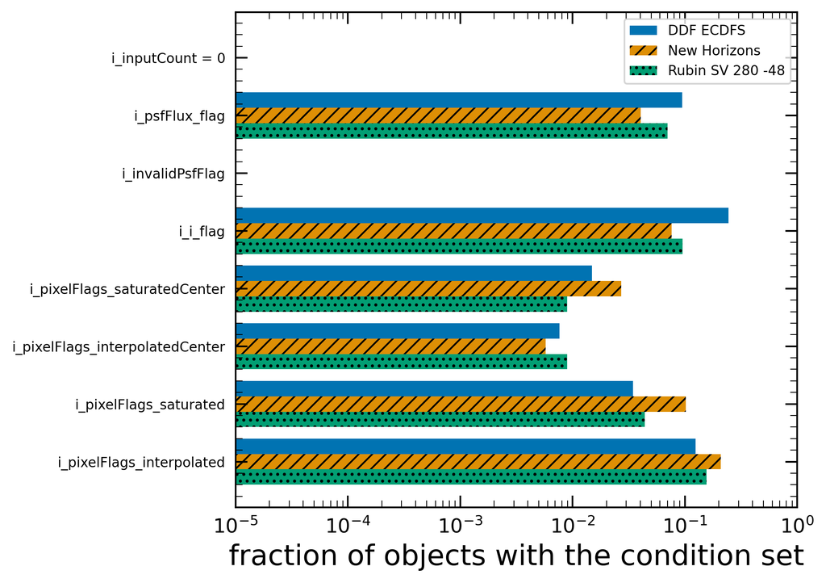

```python
hatches = ['', '///', '...', 'xxx']
positions = np.arange(len(compare_names))
width = 0.8 / max(len(occupancy), 1)
floor = 1.0e-5

fig, ax = plt.subplots(figsize=(7, 5))
for offset, (name, values) in enumerate(occupancy.items()):
    heights = np.array([values[flag_name] for flag_name in compare_names])
    ax.barh(positions + offset * width, np.clip(heights, floor, None),
            height=width, hatch=hatches[offset % len(hatches)], label=name)
ax.set_yticks(positions + 0.4 - width / 2)
ax.set_yticklabels(compare_names, fontsize=8)
ax.set_xscale('log')
ax.set_xlim(floor, 1.0)
ax.set_xlabel('fraction of objects with the condition set')
ax.invert_yaxis()
ax.legend(fontsize=8)
plt.tight_layout()
plt.show()
```

> **Figure 5:** Grouped horizontal bar chart of the fraction of objects for which each condition is set, with one group of bars per condition and one bar per field, each field drawn with a different hatch pattern. The horizontal axis is logarithmic. Bars at the left-hand limit correspond to fractions below one in one hundred thousand, including zero. The saturation and interpolation flags track how many bright objects a field holds, and are expected to be set more often in the galactic-plane field. The measurement-failure flags respond to crowding and depth together, and `i_inputCount = 0` responds to coadd coverage alone.

Apply the baseline set of cuts from Section 3.1 to each field and compare how much of each sample survives.

```python
for name, table in field_tables.items():
    print()
    report_cut_impact(build_cuts(table), label=name)
```

```
DDF ECDFS: 2614 rows before any cuts, 2334 after all cuts (10.71% removed)
cut                                        rm alone  rm uniquely     cum kept
i_inputCount > 0                                  0            0         2614
i_psfFlux_flag = 0                              247          223         2367
i_invalidPsfFlag = 0                              0            0         2367
i_pixelFlags_saturatedCenter = 0                 39           14         2351
i_pixelFlags_interpolatedCenter = 0              20           17         2334

New Horizons: 3808 rows before any cuts, 3568 after all cuts (6.30% removed)
cut                                        rm alone  rm uniquely     cum kept
i_inputCount > 0                                  0            0         3808
i_psfFlux_flag = 0                              154          126         3654
i_invalidPsfFlag = 0                              0            0         3654
i_pixelFlags_saturatedCenter = 0                103           71         3578
i_pixelFlags_interpolatedCenter = 0              22           10         3568

Rubin SV 280 -48: 1896 rows before any cuts, 1744 after all cuts (8.02% removed)
cut                                        rm alone  rm uniquely     cum kept
i_inputCount > 0                                  0            0         1896
i_psfFlux_flag = 0                              133          123         1763
i_invalidPsfFlag = 0                              0            0         1763
i_pixelFlags_saturatedCenter = 0                 17           10         1749
i_pixelFlags_interpolatedCenter = 0              17            5         1744
```

A flag cut is therefore not a fixed property of a selection that can be quoted once. In any analysis that combines fields, or compares number counts between regions, characterize the selection separately in each region. An uncorrected difference in what the cuts remove looks exactly like a difference in the sky.

Delete the per-field tables.

```python
del field_tables, occupancy
```